# LMM analysis of spider silk investment

This notebook will present the results of *all* days’ data. Here we will use a linear-mixed model (LMM) to analyse the repeated measurements of per-capita silk investment. This notebook will essentially re-do the analysis done in the first version of the paper with the non-parametric `nparLD` method. The `nparLD` method is a non-parametric ANOVA type method which handles longitudinal data. One of the constraints of the method is that all ‘subjects’ (unit of repeated measurements) must have the same sample size, and no missing values are tolerated. This essentially meant we did not include >5 days data for the initial round. LMMs can handle repeated measurements with differences in sample size, and so we can analyse all data with this method.

```r
library(arm)
library(coda)
library(gplots)
library(ggplot2)
library(lme4)
#library(rstanarm)
#library(shinystan)
load('dlenth.Rdata')
load('wd.Rdata')

set.seed(82319)
#dlenth <- subset(dlenth)
get.hpdintervals <- function(x,probrange=0.93)
{HPDinterval(as.mcmc(x),prob=probrange)}
get.med.hpdintervals <- function(x,probrange=0.93)
          {
          hpd.interval<-get.hpdintervals(x,probrange)
          med <- median(x)
          output <- c(hpd.interval[1],med,hpd.interval[2])
            }
get.prob.negative <- function(x){mean(x<0)}
get.prob.greater1 <- function(x){mean(x>1)}
get.prob.greater.value <- function(x,value){mean(x>value)}
get.prob.lesser.value <- function(x,value){mean(x<value)}
dlenth.nona <- dlenth[!is.na(dlenth$percap),]
dlenth.nona$sqrtpercap <- sqrt(dlenth.nona$percap)

# write wd to a csv file
write.csv(wd, 'wd.csv')
```

Having loaded the necessary packages and data, let’s proceed to run the linear-mixed models.

## Does per-capita silk investment decrease with increasing group sizes?

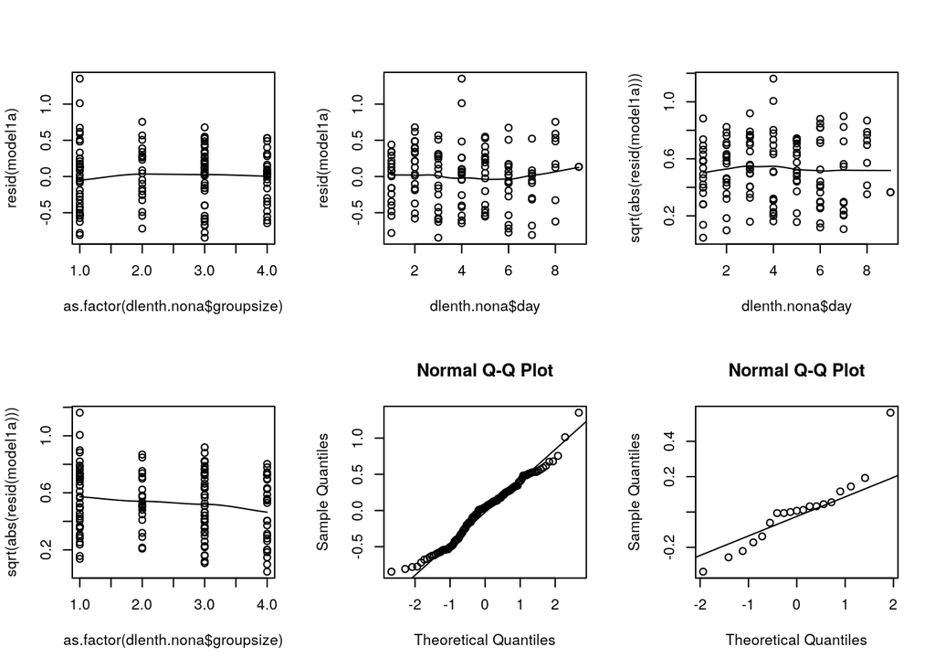

```r
# this model mimics the structure of the non-parameteric nparLD test
m1a.formula <- formula(sqrtpercap~groupsize+day+day*groupsize+(1|colonyname))
model1a <-  lmer(m1a.formula, data=dlenth.nona)

par(mfrow=c(2,3))
# residuals vs group size
scatter.smooth(as.factor(dlenth.nona$groupsize), resid(model1a),)
# residuals vs day
scatter.smooth(dlenth.nona$day,resid(model1a))
# sqrt(abs(residuals))
scatter.smooth(dlenth.nona$day, sqrt(abs(resid(model1a))))
# sqrt resids - groupsize
scatter.smooth(as.factor(dlenth.nona$groupsize), sqrt(abs(resid(model1a))))

# qqplot model residuals
qqnorm(resid(model1a));qqline(resid(model1a))
# qqplot random effects
qqnorm(ranef(model1a)$colonyname$'(Intercept)');
qqline(ranef(model1a)$colonyname$'(Intercept)')
```

The assumptions of the model are met pretty well.

```r
m1a.sim <- sim(model1a, n.sim=5000)

# get the fixed effects HPD and compare them across group sizes:
fixedefs1a.hpd <- apply(m1a.sim@fixef,2,get.hpdintervals,probrange=0.93)
fixedefs1a.mean <- apply(m1a.sim@fixef,2,mean)
fixedefs1a.all <- round(rbind(fixedefs1a.hpd[1,],fixedefs1a.mean, fixedefs1a.hpd[2,]),2)

# display the 93% compatibility interval (lower, mean, upper) for the fixed effects
print(fixedefs1a.all)
```

```
##                 (Intercept) groupsize   day groupsize:day
##                        0.51     -0.02 -0.05         -0.01
## fixedefs1a.mean        0.77      0.00  0.00          0.00
##                        1.04      0.03  0.05          0.00
```

Model 1a with the $groupsize:day$ interaction represents what I think is the most biologically motivated model. Each groupsize may respond differently over time (eg. based on the amount of silk already available/the space occupied on the frame), as is represented by the interaction.

What if we convert groupsize and time to factors?

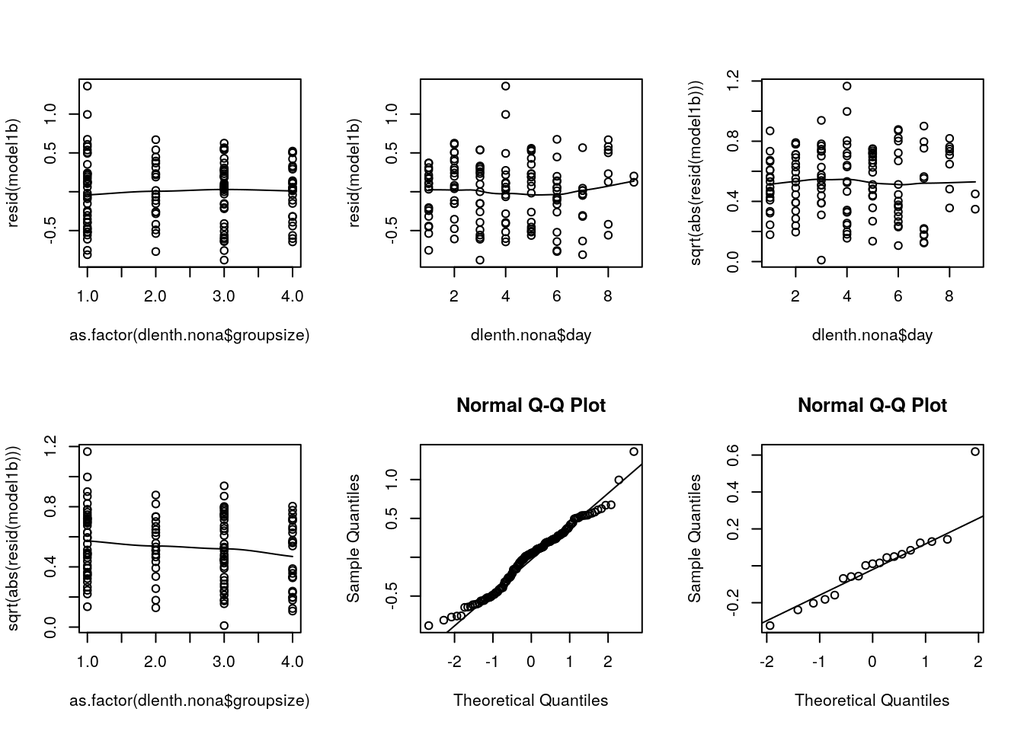

```r
dlenth.nona$fact.groupsize <- as.factor(dlenth.nona$groupsize)

m1b.formula <- formula(sqrtpercap~fact.groupsize+day+day*fact.groupsize+(1|colonyname))
model1b <-  lmer(m1b.formula, data=dlenth.nona)


par(mfrow=c(2,3))
# residuals vs group size
scatter.smooth(as.factor(dlenth.nona$groupsize), resid(model1b),)
# residuals vs day
scatter.smooth(dlenth.nona$day,resid(model1b))
# sqrt(abs(residuals))
scatter.smooth(dlenth.nona$day, sqrt(abs(resid(model1b))))
# sqrt resids - groupsize
scatter.smooth(as.factor(dlenth.nona$groupsize), sqrt(abs(resid(model1b))))

# qqplot model residuals
qqnorm(resid(model1b));qqline(resid(model1b))
# qqplot random effects
qqnorm(ranef(model1b)$colonyname$'(Intercept)');
qqline(ranef(model1b)$colonyname$'(Intercept)')
```

```r
m1b.sim <- sim(model1b, n.sim=5000)

# get the fixed effects HPD and compare them across group sizes:
fixedefs1b.hpd <- apply(m1b.sim@fixef,2,get.hpdintervals,probrange=0.93)
fixedefs1b.mean <- apply(m1b.sim@fixef,2,mean)
fixedefs1b.all <- round(rbind(fixedefs1b.hpd[1,],fixedefs1b.mean, fixedefs1b.hpd[2,]),2)

# display the 93% compatibility interval (lower, mean, upper) for the fixed effects
print(fixedefs1b.all)
```

```
##                 (Intercept) fact.groupsize5 fact.groupsize10 fact.groupsize25
##                        0.38           -0.45            -0.29            -0.42
## fixedefs1b.mean        0.71            0.10             0.17             0.09
##                        1.03            0.66             0.65             0.63
##                   day fact.groupsize5:day fact.groupsize10:day
##                 -0.06                -0.1                -0.13
## fixedefs1b.mean  0.00                 0.0                -0.04
##                  0.06                 0.1                 0.03
##                 fact.groupsize25:day
##                                -0.15
## fixedefs1b.mean                -0.05
##                                 0.04
```

Having created the models, let’s now interpret the coefficients, by looking at them in the linear scale. The models were run using the $\sqrt[2]per-capita$ silk.

```r
# per-capita silk investment across group sizes
m1a.sqrtpercap.1.5.10.25 <- cbind(m1a.sim@fixef[,1]+m1a.sim@fixef[,2],
                              m1a.sim@fixef[,1]+m1a.sim@fixef[,2]*5,
                              m1a.sim@fixef[,1]+m1a.sim@fixef[,2]*10,
                              m1a.sim@fixef[,1]+m1a.sim@fixef[,2]*25)
m1a.percap.1.5.10.25 <- m1a.sqrtpercap.1.5.10.25^2
m1a.percap.median <- apply(m1a.percap.1.5.10.25, 2, median)
m1a.percap.hpd <- apply(m1a.percap.1.5.10.25, 2, get.hpdintervals)
m1a.percap.interval <- rbind(m1a.percap.hpd[1,],m1a.percap.median,m1a.percap.hpd[2,])
```

From the Model 1a, where groupsize is continuous, we see the per-capita silk investments are overlapping across the group-sizes. To be sure, let’s also check the output from Model 1b, where groupsize is treated as a factor

```r
m1b.sqrtpercap.1.5.10.25 <- cbind(m1b.sim@fixef[,1],
                              m1b.sim@fixef[,1]+m1b.sim@fixef[,2],
                              m1b.sim@fixef[,1]+m1b.sim@fixef[,3],
                              m1b.sim@fixef[,1]+m1b.sim@fixef[,4])
m1b.percap.1.5.10.25 <- m1b.sqrtpercap.1.5.10.25^2
m1b.percap.median <- apply(m1b.percap.1.5.10.25, 2, median)
m1b.percap.hpd <- apply(m1b.percap.1.5.10.25, 2, get.hpdintervals)
m1b.percap.interval <- rbind(m1b.percap.hpd[1,],m1b.percap.median,m1b.percap.hpd[2,])
```

To visualise the coefficients obtained from group-sizes, let us plot the median and 93% HPD ranges from both Model1a and Model1b.

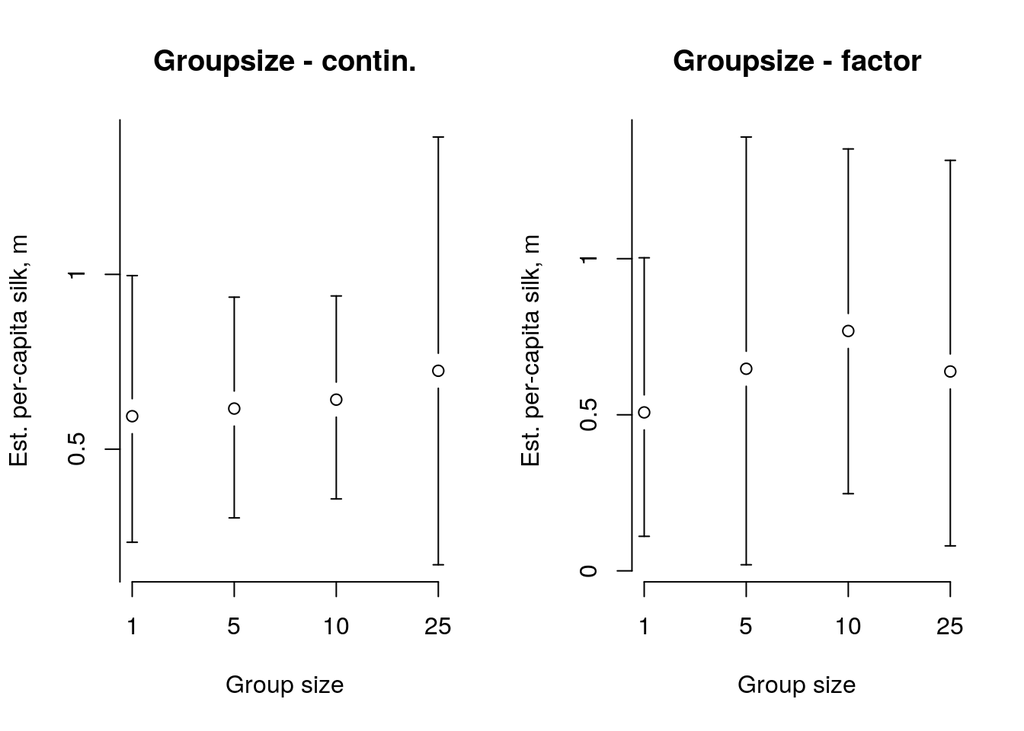

```r
# model1a - groupsize as continuous
groupsizes <- c(1,5,10,25)
frame()
par(mfrow=c(1,2))
plotCI(seq(1,4),y=m1a.percap.interval[2,],li=m1a.percap.interval[1,],ui=m1a.percap.interval[3,], main='Groupsize - contin.',ylab = 'Est. per-capita silk, m',, xlab='Group size', axes=F)
axis(1, at=1:4, labels=groupsizes);axis(2, at=seq(0,2,0.5), labels=seq(0,2,0.5))
plotCI(seq(1,4),y=m1b.percap.interval[2,],li=m1b.percap.interval[1,],ui=m1b.percap.interval[3,],main='Groupsize - factor',ylab = 'Est. per-capita silk, m', xlab='Group size', axes=F)
axis(1, at=1:4, labels=groupsizes);axis(2, at=seq(0,2,0.5), labels=seq(0,2,0.5))
```

Let us also generate some comparitive estimates. How much fold is per-capita increased or decreased in comparison to single-spiders?

```r
m1a.fold.change <- m1a.percap.1.5.10.25[,2:4]/m1a.percap.1.5.10.25[,1]
m1b.fold.change <- m1b.percap.1.5.10.25[,2:4]/m1b.percap.1.5.10.25[,1]

m1a.fold.hpd <- apply(m1a.fold.change,2,get.med.hpdintervals)
m1b.fold.hpd <- apply(m1b.fold.change,2,get.med.hpdintervals)
```

Having generated the estimated per-capita silk with group size, let us now calculate a derived parameter: the relative silk investment ratio ($\frac{Group \:per-capita}{Single \:per-capita}$). If the parameter is estimated to be mostly less than one, this is evidence for a decrease in per-capita silk investment with group size.

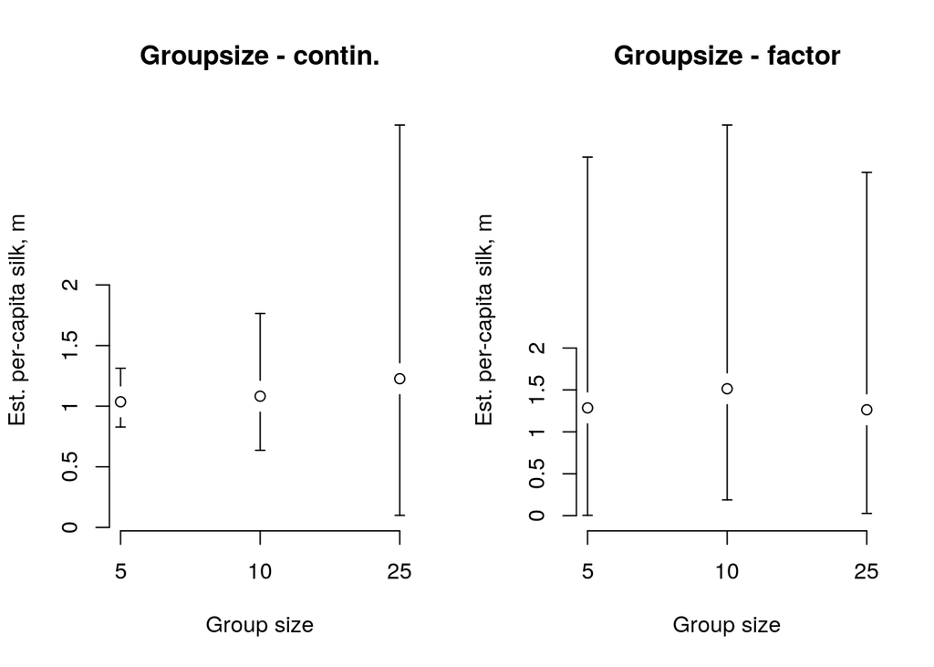

```r
frame()
par(mfrow=c(1,2))
plotCI(seq(1,3),y=m1a.fold.hpd[2,],li=m1a.fold.hpd[1,],ui=m1a.fold.hpd[3,], main='Groupsize - contin.',ylab = 'Est. per-capita silk, m',, xlab='Group size', axes=F)
axis(1, at=1:3, labels=groupsizes[2:4]);axis(2, at=seq(0,2,0.5), labels=seq(0,2,0.5))
plotCI(seq(1,3),y=m1b.fold.hpd[2,],li=m1b.fold.hpd[1,],ui=m1b.fold.hpd[3,],main='Groupsize - factor',ylab = 'Est. per-capita silk, m', xlab='Group size', axes=F)
axis(1, at=1:3, labels=groupsizes[2:4]);axis(2, at=seq(0,2,0.5), labels=seq(0,2,0.5))
```

Both models do not seem to strongly support a situation where per-capita is lower than in single spiders. Across group-sizes 5,10 and 25 the $P(\frac{group\:per-capita}{single\:per-capita}<1)=$ 0.37, 0.37, 0.37 for Model 1a, and $P(\frac{group\:per-capita}{single\:per-capita}<1)=$ 0.38, 0.26, 0.39 for Model 1b. Both models seem to weakly suggest a situation where per-capita silk investment increase with group-sizes. As can be seen, the compatibility intervals are somewhat wide, perhaps due to the low sample-sizes, and inherent variation in the data itself.

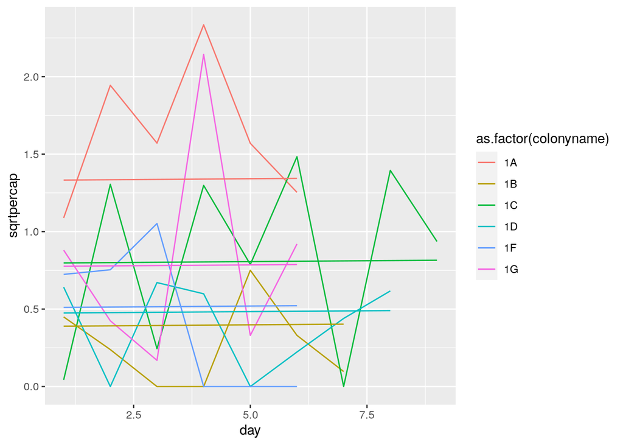

```r
dlenth.nona$pred.m1b <- predict(model1b)
dlenth.nona$pred.m1a <- predict(model1a)

par(mfrow=c(2,2))
# 1 spider
ggplot(subset(dlenth.nona,groupsize==1))+geom_line(aes(x=day,y=sqrtpercap,color=as.factor(colonyname),group=colonyname))+geom_line(aes(x=day,y=pred.m1b,color=as.factor(colonyname),group=colonyname))
```

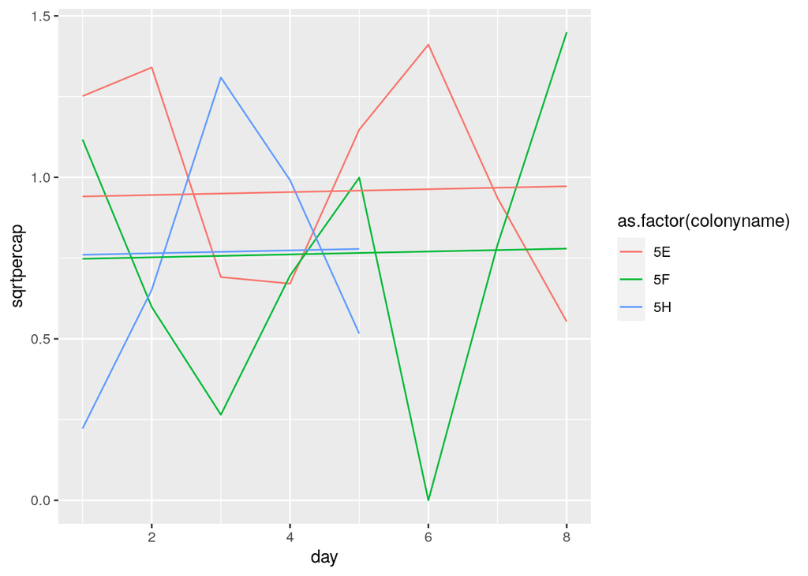

```r
# 5 spider
ggplot(subset(dlenth.nona,groupsize==5))+geom_line(aes(x=day,y=sqrtpercap,color=as.factor(colonyname),group=colonyname))+geom_line(aes(x=day,y=pred.m1b,color=as.factor(colonyname),group=colonyname))
```

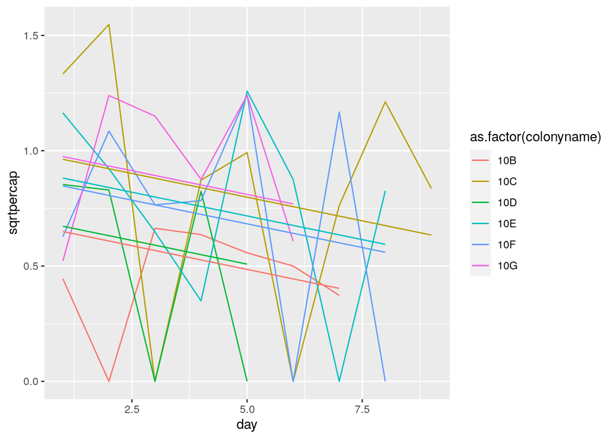

```r
# 10 spider
ggplot(subset(dlenth.nona,groupsize==10))+geom_line(aes(x=day,y=sqrtpercap,color=as.factor(colonyname),group=colonyname))+geom_line(aes(x=day,y=pred.m1b,color=as.factor(colonyname),group=colonyname))
```

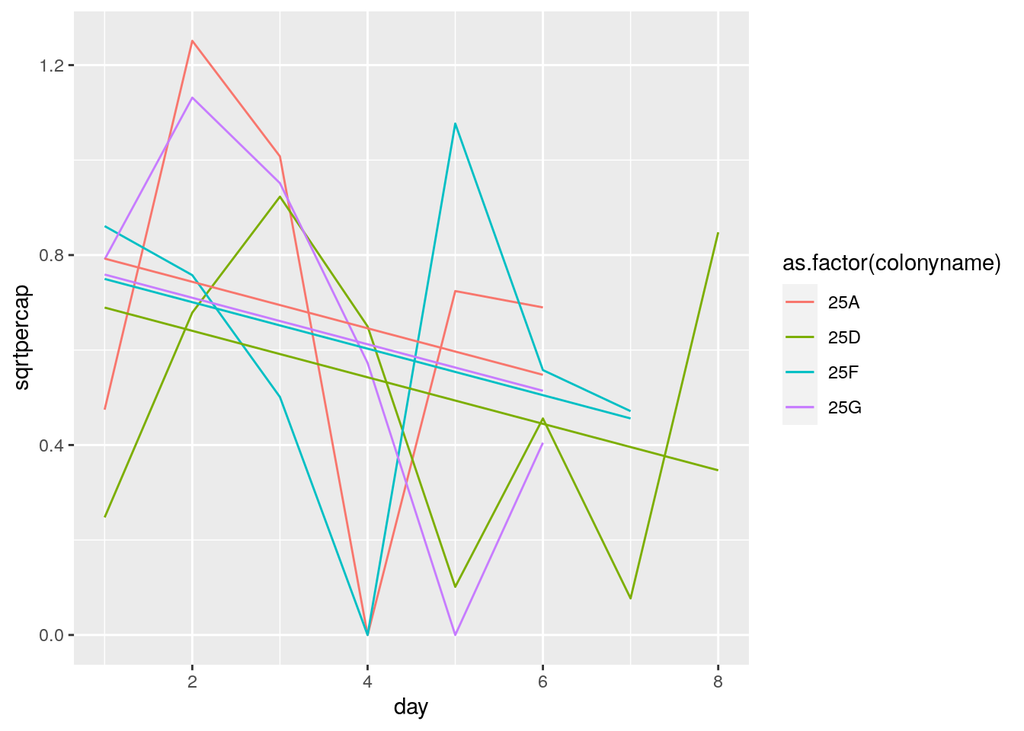

```r
# 25 spider
ggplot(subset(dlenth.nona,groupsize==25))+geom_line(aes(x=day,y=sqrtpercap,color=as.factor(colonyname),group=colonyname))+geom_line(aes(x=day,y=pred.m1b,color=as.factor(colonyname),group=colonyname))
```

## How does overall silk change with group-size?

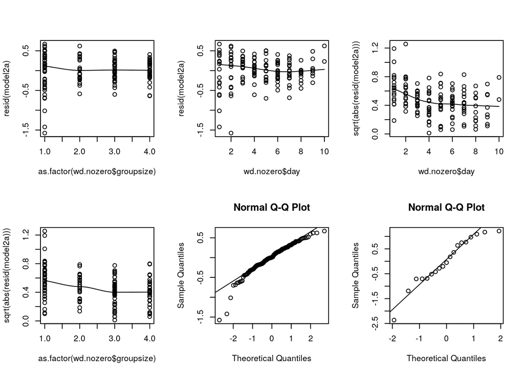

```r
# this is model1 but with group size as  factor for easier comparison
wd.nozero <- subset(wd, Lengthm>0)
wd.nozero$sqrtm <- sqrt(wd.nozero$Lengthm+10^-5)
wd.nozero$logm <- log(wd.nozero$Lengthm+10^-3)
model2a <- lmer(logm~day+I(day^2)+groupsize+groupsize*day+(1|colonyname), data=wd.nozero)
# diagnose the model fit

frame()
par(mfrow=c(2,3))
# residuals vs group size
scatter.smooth(as.factor(wd.nozero$groupsize), resid(model2a),)
# residuals vs day
scatter.smooth(wd.nozero$day,resid(model2a))
# sqrt(abs(residuals))
scatter.smooth(wd.nozero$day, sqrt(abs(resid(model2a))))
# sqrt resids - groupsize
scatter.smooth(as.factor(wd.nozero$groupsize), sqrt(abs(resid(model2a))))

# qqplot model residuals
qqnorm(resid(model2a));qqline(resid(model2a))
# qqplot random effects
qqnorm(ranef(model2a)$colonyname$'(Intercept)');
qqline(ranef(model2a)$colonyname$'(Intercept)')
```

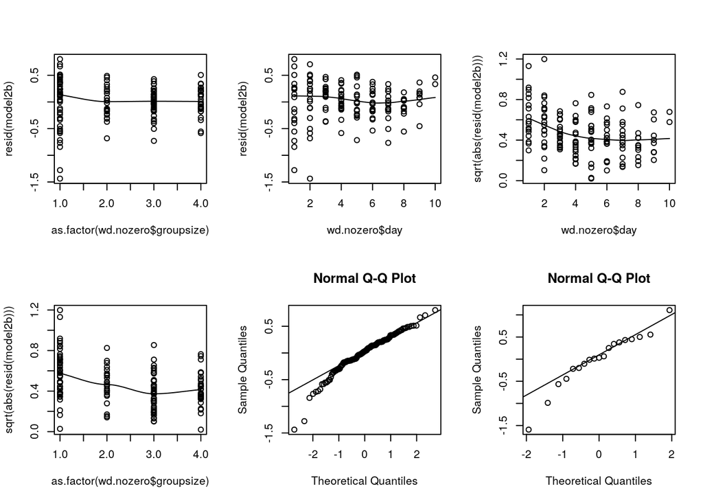

```r
# this is model1 but with group size as  factor for easier comparison
wd.nozero$fact.groupsize <- as.factor(wd.nozero$groupsize)
model2b <- lmer(logm~day+I(day^2)+fact.groupsize+fact.groupsize*day+(1|colonyname), data=wd.nozero)
# diagnose the model fits

frame()
par(mfrow=c(2,3))
# residuals vs group size
scatter.smooth(as.factor(wd.nozero$groupsize), resid(model2b),)
# residuals vs day
scatter.smooth(wd.nozero$day,resid(model2b))
# sqrt(abs(residuals))
scatter.smooth(wd.nozero$day, sqrt(abs(resid(model2b))))
# sqrt resids - groupsize
scatter.smooth(as.factor(wd.nozero$groupsize), sqrt(abs(resid(model2b))))

# qqplot model residuals
qqnorm(resid(model2b));qqline(resid(model2b))
# qqplot random effects
qqnorm(ranef(model2b)$colonyname$'(Intercept)');
qqline(ranef(model2b)$colonyname$'(Intercept)')
```

```r
nruns <- 10^4
m2a.sim <- sim(model2a, n.sim=nruns)
m2b.sim <- sim(model2b, n.sim=nruns)

m2a.fixefs.hpd <- apply(m2a.sim@fixef,2,get.hpdintervals)
m2b.fixefs.hpd <- apply(m2b.sim@fixef,2,get.hpdintervals)
print(m2a.fixefs.hpd)
```

```
##      (Intercept)       day    I(day^2) groupsize day:groupsize
## [1,]  -1.5653357 0.5894387 -0.04833276 0.1193053  -0.009389975
## [2,]  -0.2754916 0.7959936 -0.02867194 0.2172807  -0.003685137
```

```r
print(m2b.fixefs.hpd)
```

```
##      (Intercept)       day    I(day^2) fact.groupsize5 fact.groupsize10
## [1,]   -2.304779 0.6167561 -0.04762057        1.533564         2.540042
## [2,]   -1.153174 0.8271931 -0.02787742        3.468676         4.096565
##      fact.groupsize25 day:fact.groupsize5 day:fact.groupsize10
## [1,]         3.498179         -0.17464766          -0.18061156
## [2,]         5.252339         -0.03148323          -0.06414223
##      day:fact.groupsize25
## [1,]          -0.23765925
## [2,]          -0.09819351
```

```r
# the total relative silk investment w.ref to single spiders on day 1

rel.coefs.m2a <- exp(cbind(m2a.sim@fixef[,1]+m2a.sim@fixef[,2]+m2a.sim@fixef[,3]+m2a.sim@fixef[,4]+m2a.sim@fixef[,5],
                       m2a.sim@fixef[,1]+m2a.sim@fixef[,2]+m2a.sim@fixef[,3]+(m2a.sim@fixef[,4]+m2a.sim@fixef[,5])*5,
                       m2a.sim@fixef[,1]+m2a.sim@fixef[,2]+m2a.sim@fixef[,3]+(m2a.sim@fixef[,4]+m2a.sim@fixef[,5])*10,
                       m2a.sim@fixef[,1]+m2a.sim@fixef[,2]+m2a.sim@fixef[,3]+(m2a.sim@fixef[,4]+m2a.sim@fixef[,5])*25))

rel.totalsilk.m2a <- rel.coefs.m2a[,2:4]/rel.coefs.m2a[,1]

fefs.m2b <- m2b.sim@fixef
rel.coefs.m2b.num <- cbind(apply(fefs.m2b[,1:3],1,sum),
                       apply(fefs.m2b[,c(1:4,7)],1,sum),
                       apply(fefs.m2b[,c(1:3,5,8)],1,sum),
                       apply(fefs.m2b[,c(1:3,6,9)],1,sum))
rel.coefs.m2b.num <- exp(rel.coefs.m2b.num)

rel.totalsilk.m2b <- matrix(data=NA,nrow=nruns,ncol=3)
rel.totalsilk.m2b[,1] <- rel.coefs.m2b.num[,2]/rel.coefs.m2b.num[,1]
rel.totalsilk.m2b[,2] <- rel.coefs.m2b.num[,3]/rel.coefs.m2b.num[,1]
rel.totalsilk.m2b[,3] <- rel.coefs.m2b.num[,4]/rel.coefs.m2b.num[,1]


reltotal.m2a.hpd <- apply(rel.totalsilk.m2a,2,get.med.hpdintervals)
reltotal.m2b.hpd <- apply(rel.totalsilk.m2b,2,get.med.hpdintervals)

print(reltotal.m2a.hpd)
```

```
##          [,1]     [,2]       [,3]
## [1,] 1.536976 2.549721   9.886611
## [2,] 1.911316 4.295348  48.752343
## [3,] 2.276614 6.270629 125.762581
```

```r
print(reltotal.m2b.hpd)
```

```
##           [,1]      [,2]      [,3]
## [1,]  3.217379  8.591709  21.69749
## [2,] 11.175665 24.146157  65.48445
## [3,] 25.027140 45.872936 136.60270
```

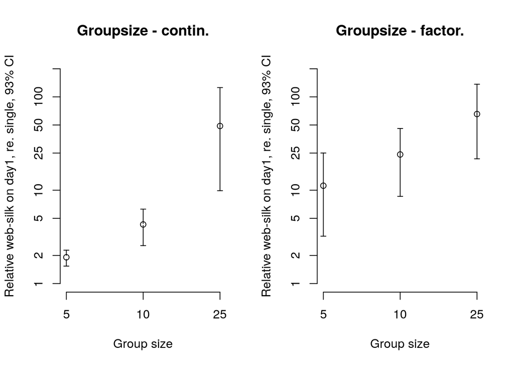

```r
gpsizes <- c(5,10,25)
frame()
par(mfrow=c(1,2))
plotCI(seq(1,3),y=reltotal.m2a.hpd[2,],
                li=reltotal.m2a.hpd[1,],
                ui=reltotal.m2a.hpd[3,],
                main='Groupsize - contin.',
               ylab = 'Relative web-silk on day1, re. single, 93% CI', xlab='Group size',log='y', axes=F,ylim=c(1,200))
axis(1, at=1:3, labels=gpsizes);axis(2, at=c(1,2,5,10,25,50,100,200), labels=c(1,2,5,10,25,50,100,200))
plotCI(seq(1,3),y=reltotal.m2b.hpd[2,],
                li=reltotal.m2b.hpd[1,],
                ui=reltotal.m2b.hpd[3,],
                main='Groupsize - factor.',
               ylab = 'Relative web-silk on day1, re. single, 93% CI', xlab='Group size',log='y',axes=F,ylim=c(1,200))
axis(1, at=1:3, labels=gpsizes);axis(2, at=c(1,2,5,10,25,50,100,200), labels=c(1,2,5,10,25,50,100,200))
```

It is important to remember these estimates are likely to be indicative, and perhaps not be taken too literally. The linear mixed model is a phenomological model with no explicit behavioural mechanisms in place, and provides us a rough estimate of the web dynamics. A more reliable estimate of relative silk investment in groups could be obtained by parametrising a detailed mechanistically based model.